# Modelling spatio-temporal processes

## 0. How do R markdown files work?

- load them with rstudio
- click the `knit` button
- debug/step through:
  - load all code up to here-button
  - ctrl-Enter: run this line
  - output in console, objects appear in Environment browser

## 1. Course overview, time series

### 1.1 Literature

- C. Chatfield, The analysis of time series: an introduction. Chapman and Hall: chapters 1, 2 and 3
- Applied Spatial Data Analysis with R, by R. Bivand, E. Pebesma and V. Gomez-Rubio (Springer; [first edition](http://www.springer.com/978-0-387-78170-9) or its [second edition](http://www.springer.com/statistics/life+sciences%2C+medicine+%26+health/book/978-1-4614-7617-7)):
  - Ch 1, 2, 3
  - Ch 4, 5
  - 1st ed, Ch 6 (customizing classes for spatial data) or 2nd ed, Ch 6 (spatio-temporal data)
  - Ch 8 (geostatistics)

### 1.2 Organization

Teachers:

- Christian Knoth (exercises, Wed 12-14)
- Edzer Pebesma (lectures)

Learnweb:

- subscribe! no password! Only one course!

Slides:

- html on http://edzer.github.io/mstp/
- Rmd sources on on http://github.com/edzer/mstp
- you can run the Rmd files in rstudio (http://www.rstudio.com/)
- pull requests with improvements are appreciated (and may be rewarded)

### 1.3 examen:

- multiple choice, 4 possibilities, 40 questions, 20 need to be correct.

### 1.4 Overview of the course

Topics:

- Time series data
- Time series models: AR(p), MA(q), partial correlation, AIC, forecasting
- Optimisation:
  - Linear models, least squares: normal equations
  - Non-linear:
    - One-dimensional: golden search
    - Multi-dimensional least squares: Newton
    - Multi-dimensional stochastic search: Metropolis
    - Multi-dimensional stochastic optimisation: Metropolis
- Spatial models:
  - Simple, heuristic spatial interpolation approaches
  - Spatial correlation
  - Regression with spatially correlated data
  - Kriging: best linear (unbiased) prediction
  - Stationarity, variogram
  - Kriging varieties: simple, ordinary, universal kriging
  - Kriging as a probabilistic spatial predictor
- Spatio-temporal variation modelled by partial differential equations
  - Initial and boundary conditions
  - Example
  - Calibration: Kalman filter

## 2. Where we come from

- introduction to geostatistics
- mathematics, linear algebra
- computer science

### 2.1 introduction to geostatistics

- types of variables: Stevens' measurement scales – nominal, ordinal, interval, ratio
- … or: discrete, continuous
- t-tests, ANOVA
- regression, multiple regression (but not how we compute it)
- assumption was: observations are *independent*
- what does independence mean?

### 2.2 In this course

- we will study dependence in observations, in
  - space
  - time
  - or space-time
- in space and/or time, Stevens' measurement scales are not enough! Examples:
  - linear time, cyclic time
  - space: functions, fields
- we will study how we can represent phenomena, by
  - mathematical representations (models)
  - computer representations (models)
- we will consider how well these models correspond to our observations

## 3. Spatio-temporal phenomena are everywhere

- if we think about it, there are no data that can be non-spatial or non-temporal.
- in many cases, the spatial or temporal references are not essential
  - think: brain image of a person: time matters, but mostly referenced with respect to the age of the person, spatial location of the MRI scanner does not
  - but: ID of the patient does!
  - and: time of scan matters too!
- we will “pigeon-hole'' (classify) phenomena into: fields, objects, aggregations

### 3.1 fields

- many processes can be represented by fields, meaning they could be measured everywhere
- think: temperature in this room
- typical problems: interpolation, patterns, trends, temporal development, forecasting?

### 3.2 objects and events

- objects can be identified
- objects are identified within a frame (or *window*) of observation
- within this window, between objects, there are no objects (no point of interpolation)
- objects can be moving (people), or static (buildings)
- objects or events are sometimes obtained by thresholding fields, think heat wave, earthquake, hurricane, see e.g. [http://ifgi.uni-muenster.de/~j_jone02/publications/GIScience2014.pdf](http://ifgi.uni-muenster.de/%7Ej_jone02/publications/GIScience2014.pdf)
- sometimes this view is rather artificial, think cars, persons, buildings

### 3.3 fields - objects/events conversions

- we can convert a field into an object by thresholding (wind field, storm or hurricane)
- we can convert objects into a field e.g. by computing the density as a continuous function

### 3.4 aggregations

- we can aggregate fields, or objects, but do this differently:
- population can be summed, temperature cannot

## 3.5 Aims of modelling

… could be

- curiousity
- studying models is easier than measuring the world around us

More scientific aims of modelling are

- to learn about the world around us
- to predict the past, current or future, in case where measurement is not feasible.

### 3.5 What is a model?

- conceptual models (the water cycle: http://en.wikipedia.org/wiki/File:Water_cycle.png)
- object models (e.g., UML: http://en.wikipedia.org/wiki/File:UML_diagrams_overview.svg)
- mathematical models, such as Navier Stokes' equation,

[figure not shown]

### 3.6 What is a mathematical model?

A mathematical model is an abstract model that uses mathematical language to describe the behaviour of a system.

> a representation of the essential aspects of an existing system (or a system to be constructed) which presents knowledge of that system in usable form (P. Eykhoff, 1974, System Identification, J. Wiley, London.)

In the natural sciences, a model is always an approximation, a simplification of reality. If degree of approximation meets the required accuracy, the model is useful, or valid (of value). A validated model does not imply that the model is true''; more than one model can be valid at the same time.

## 4. Time series models

we will first look into time series models, because they are

- simple
- easy to write down
- well understood

time series models are roughly divided in

1. time domain models and, which look at correlations and memory
2. frequency domain models, which focus on periodicities

Spatial equivalents are mostly found in (a), although (b) has spatial equivalences as well (e.g. wavelets).

### 4.1 some data

Consider the following process (\(\Delta t\) = 1 min):

```r
load("meteo.RData") # should be available in the current working directory
ls()
```

```
##  [1] "e"           "e20"         "e5"          "grd"         "i"
##  [6] "m"           "meteo"       "meuse"       "meuse.grid"  "meuse.riv"
## [11] "meuse.sr"    "meuse.th"    "n"           "pts"         "R"
## [16] "rw1"         "rw2"         "rw3"         "v"           "white.noise"
## [21] "x"           "X"           "xpts"        "y"           "y2"
```

```r
names(meteo)
```

```
##  [1] "ID"            "year"          "julian.day"    "time"
##  [5] "T.outside"     "pressure"      "humidity"      "X"
##  [9] "windspeed"     "std.dev."      "Wind.dir"      "std.dev..1"
## [13] "TippingBucket" "mins"          "hours"         "date"
## [17] "T.per"
```

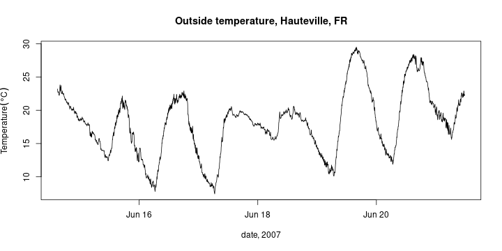

```r
plot(T.outside~date, meteo, type='l', ylab = parse(text = "Temperature ({}*degree* C)"), xlab = "date, 2007")
title("Outside temperature, Hauteville, FR")
```

### 4.2 Questions

- how can we describe this process in statistical terms?
- how can we model this process?
- (how) can we predict future observations?

### 4.3 White noise, and AR(\(n\))

Perhaps the simplest time series model is *white noise* with mean \(m\):

\[y_t = m + e_t, \ \ e_t \sim N(0,\sigma^2)\]

\(N(0,\sigma^2)\) denoting the normal distribution with mean 0 and variance \(\sigma^2\), and \(\sim\) meaning *distributed as* or *coming from*.

\(t\) is the index \(t=1,2,…,n\) of the observation, and refers to specific times, which, when not otherwise specified are at regular intervals.

A *white noise* process is completely without memory: each observation is independent from its past or future. Plotting independent, standard normal values against their index (the default for plotting a vector in R) shows how a white noise time series would look like:

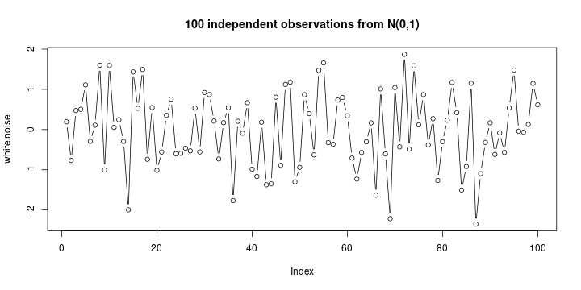

```r
white.noise = rnorm(100)
plot(white.noise, type='b')
title("100 independent observations from N(0,1)")
```

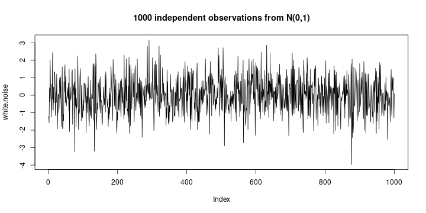

```r
white.noise = rnorm(1000)
plot(white.noise, type='l')
title("1000 independent observations from N(0,1)")
```

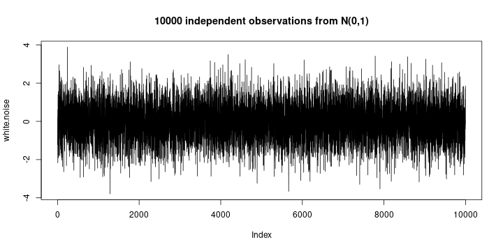

```r
white.noise = rnorm(10000)
plot(white.noise, type='l')
title("10000 independent observations from N(0,1)")
```

We can look at the auto-correlation function of a white noise process, and find it is uncorrelated for any lag larger than 0:

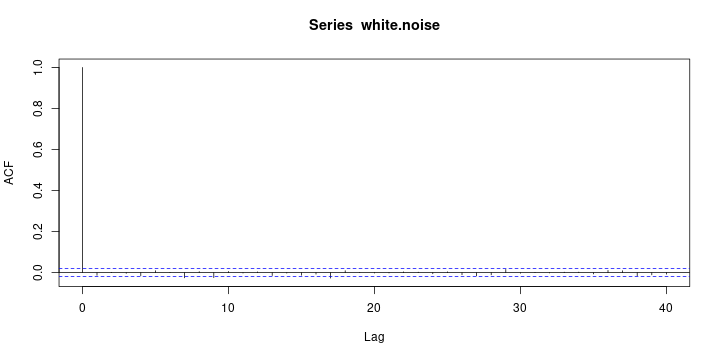

```r
plot(acf(white.noise))
```

Correlation x and y: \[ r(x,y) = \frac{\sum_{i=1}^{n}(x_i-\bar{x})(y_{i}-\bar{y})}{\sqrt{\sum_{i=1}^n (x_i-\bar{x})^2\sum_{i=1}^n(y_i-\bar{y})^2}} \]

### 4.4 Autocorrelation

Autocorrelation (or lagged correlation) is the correlation between \(y_i\) and \(y_{i+h}\), as a function of the lag \(h\): \[ r(h) = \frac{\sum_{i=1}^{n-h}(y_i-\bar{y})(y_{i+h}-\bar{y})}{\sum_{i=1}^n (y_i-\bar{y})^2} \] with \(\bar{y} = \frac{1}{n} \sum_{i=1}^n y_i\)

### 4.5 Random walk

A simple, next model to look at is that of *random walk*, where each time step a change is made according to a white noise process: \[y_t = y_{t-1} + e_t\] Such a process has memory, and long-range correlation. If we take the first-order differences, \[y_t - y_{t-1} = e_t\] we obtain the white noise process.

Further, the variance of the process increases with increasing domain (i.e., it is non-stationary)

### 4.6 Example random walk:

We can compute it as the cumulative sum of standard normal deviates: \(y_n = \sum_{i=1}^n e_i\):

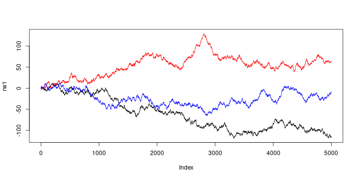

```r
# generate three series:
rw1 = cumsum(rnorm(5000))
rw2 = cumsum(rnorm(5000))
rw3 = cumsum(rnorm(5000))
plot(rw1, type='l', ylim = range(c(rw1,rw2,rw3)))
lines(rw2, type='l', col='red')
lines(rw3, type='l', col='blue')
```

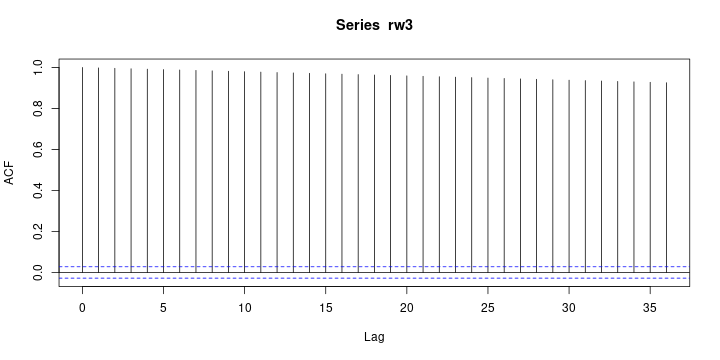

```r
plot(acf(rw3))
```

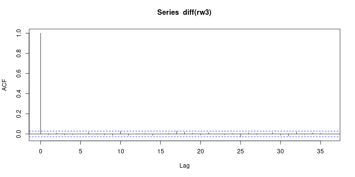

```r
plot(acf(diff(rw3)))
```

### 4.7 MA(1), MA(q)

Let \(e_t\) be a white noise process. A moving average process of order \(q\) is generated by \[y_t = \beta_0 e_t + \beta_1 e_{t-1} + … + \beta_q e_{t-q}\]

Note that the \(\beta_j\) are weights, and could be \(\frac{1}{q+1}\) to obtain an unweighted average. Moving averaging smoothes the white noise series \(e_t\).

Moving average over monthly CO2 measurements on Maunaloa:

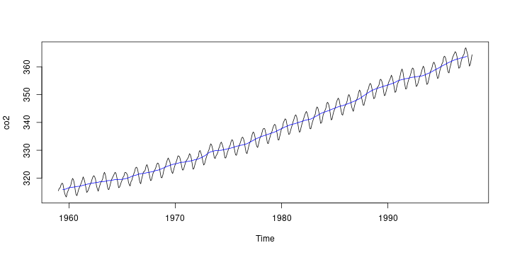

```r
plot(co2)
lines(filter(co2, rep(1/12, 12)), col='blue')
```

Moving averages over a white noise process:

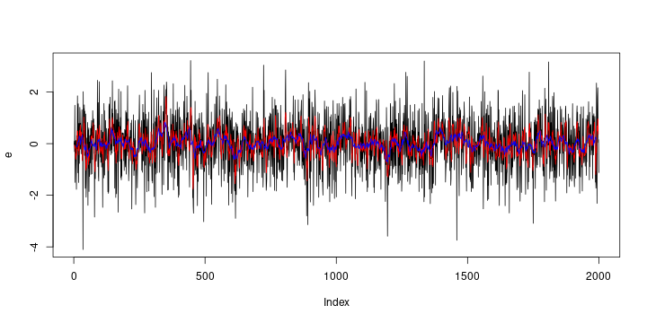

```r
#set.seed(13531)
e = rnorm(2000)
plot(e, type='l')
e5 = filter(e, rep(1/5, 5))
e20 = filter(e, rep(1/20, 20))
lines(e5, col='red')
lines(e20, col='blue')
```

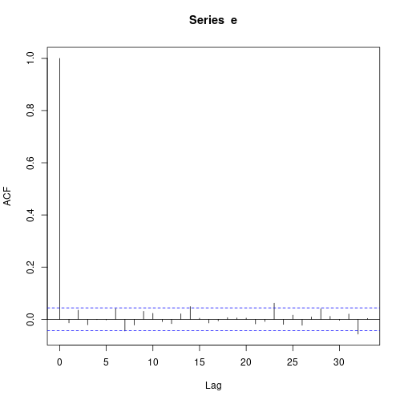

```r
acf(e)
```

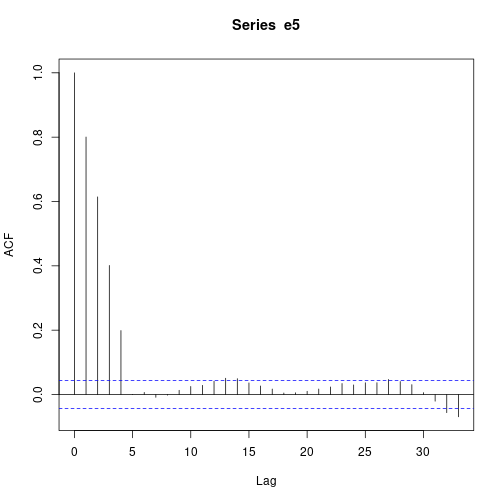

```r
acf(e5, na.action = na.pass)
```

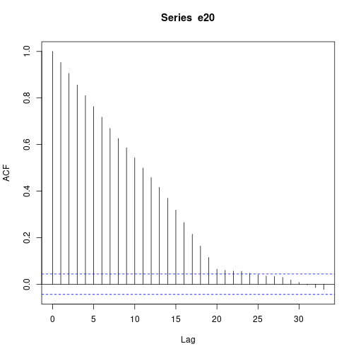

```r
acf(e20, na.action = na.pass)
```

Wider moving average filters give new processes with

- less variation
- stronger correlation, over larger lags

### 4.8 AR(1), AR(p)

An auto-regressive (1) model, or AR(1) model is generated by \[y_t = \phi_1 y_{t-1}+e_t\] and is sometimes called a Markov process. Given knowledge of \(y_{t-1}\), observations further back carry no information; more formally: \[\Pr(y_t|y_{t-1},y_{t-2},…,y_{t-q}) = \Pr(y_t|y_{t-1})\]

- \(\phi_1 = 1\) gives random walk, \(\phi_1=0\) gives white noise.
- AR(1) processes have correlations beyond lag 1
- AR(1) processes have non-significant *partial autocorrelations* beyond lag 1

As an example, we create an AR(1) process with \(\phi_1=0.85\) and \(e\) drawn from the standard normal distribution (mean 0, variance 1).

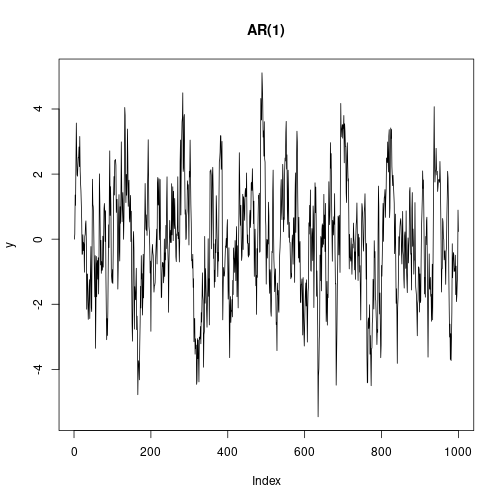

```r
y = rep(NA_real_, 1000) # initialise the variable: not needed, but good practice
y[1] = 0
for (i in 2:1000) y[i] = 0.85 * y[i-1] + rnorm(1)
plot(y, type = 'l', main = "AR(1)")
```

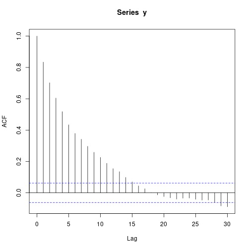

```r
plot(acf(y))
```

Compare the shape of the `acf` with that obtained from a MA process: different!

### 4.9 AR(p)

\[y_t = \phi_1 y_{t-1}+ \phi_2 y_{t-2} + … + \phi_p y_{t-p} + e_t\] or \[y_t = \sum_{j=1}^p \phi_j y_{t-j}+e_t\]

- The state of \(y_t\) does not *only* depend on \(y_{t-1}\), but observations further back contain information
- AR(p) have autocorrelations beyond lag p
- AR(p) have zero'' *partial* autocorrelations beyond lag p

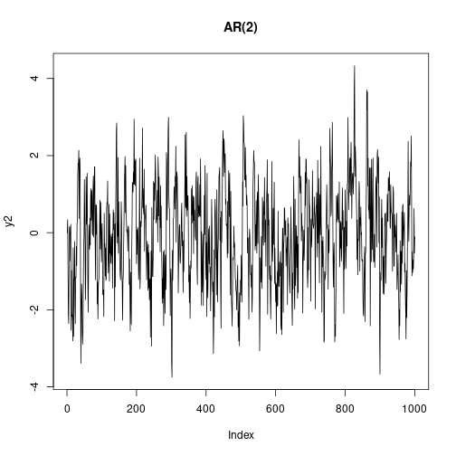

```r
y2 = rep(NA_real_, 1000) # initialise the variable: not needed, but good practice
y2[1] = 0; y2[2] = rnorm(1)
for (i in 3:1000) y2[i] = 0.5 * y2[i-1] + 0.15 * y2[i-2] + rnorm(1)
plot(y2, type = 'l', main = "AR(2)")
```

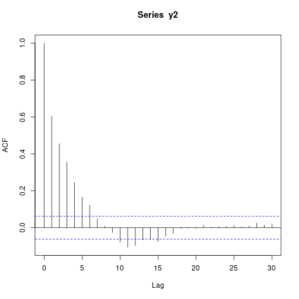

```r
plot(acf(y2))
```

### 4.10 What is partial correlation?

- Correlation between \(y_t\) and \(y_{t-2}\) is simply obtained by plotting both series of length \(n-2\), and computing correlation
- Lag-2 *partial* autocorrelation of \(y_t\) and \(y_{t-2}\), given the value inbetween \(y_{t-1}\) is obtained by
  - computing residuals \(\hat{e}_t\) from regressing of \(y_t\) on \(y_{t-1}\)
  - computing residuals \(\hat{e}_{t-2}\) from regressing of \(y_{t-2}\) on \(y_{t-1}\)
  - computing the correlation between both residual series \(\hat{e}_t\) and \(\hat{e}_{t-2}\).
- Lag-3 partial autocorrelation regresses \(y_t\) and \(y_{t-3}\) on *both* intermediate values \(y_{t-1}\) and \(y_{t-2}\)
- etc.

Partial correlation can help reveal what the order of an AR(p) series is.

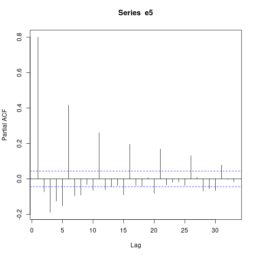

```r
plot(pacf(e5, na.action = na.omit))
```

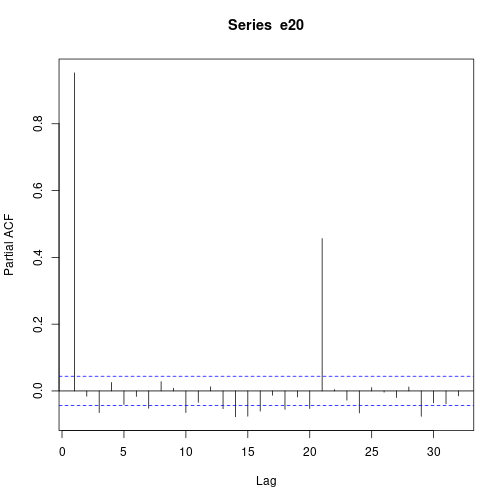

```r
plot(pacf(e20, na.action = na.omit))
```

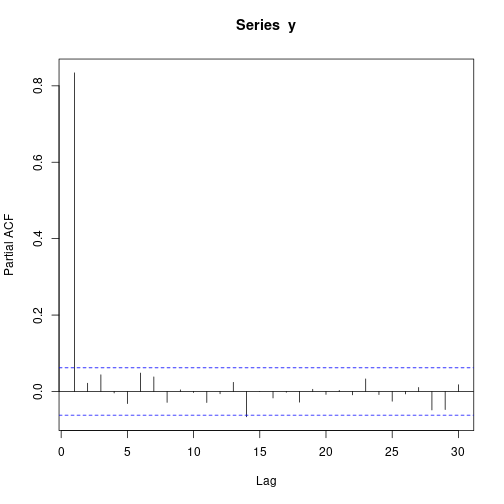

```r
plot(pacf(y))
```

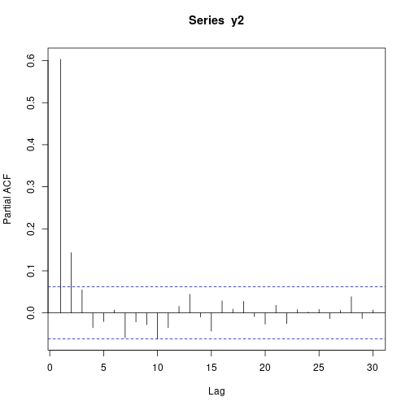

```r
plot(pacf(y2))
```